# AAPL | GARCH, Monte Carlo, árbol binomial y rentabilidad

Datos LSEG Workspace e inversión simulada en Investopedia

María Tamara López Romo, Daniel Alejandro Sánchez Aguirre, Michel Alexander Meléndez Salas

2026-11-03

# 1. Introducción

La valuación de instrumentos derivados requiere analizar tanto la evolución del precio del activo subyacente como la incertidumbre asociada a sus rendimientos. En particular, la volatilidad constituye una variable fundamental para determinar el valor de las opciones financieras y evaluar los riesgos de una estrategia de inversión.

El presente trabajo integra tres herramientas cuantitativas: el modelo GARCH(1,1), la simulación Monte Carlo y el modelo de árboles binomiales de Cox-Ross-Rubinstein (CRR), aplicados a Apple Inc. (AAPL).

Para el análisis se utilizan precios históricos diarios obtenidos de LSEG Workspace, correspondientes a un periodo aproximado de dos años. A partir de estos datos se estimará la volatilidad condicional mediante GARCH(1,1), se simularán escenarios futuros para el precio de la acción y se calculará el valor teórico de una opción Call americana.

El análisis se vincula con una operación ejecutada en el simulador de Investopedia el 27 de octubre de 2026, correspondiente a la compra de un contrato Call sobre AAPL, con precio de ejercicio de USD 345, vencimiento el 18 de diciembre de 2026 y prima de adquisición de USD 13.50 por acción.

Finalmente, se evaluarán los posibles resultados de la estrategia durante un horizonte de dos semanas, distinguiendo entre la rentabilidad observada, la valuación teórica y los escenarios proyectados.

# 2. Objetivos

**Objetivo general**

Evaluar la volatilidad y el comportamiento potencial de Apple Inc. mediante modelos cuantitativos, con el propósito de analizar la valuación y rentabilidad de una estrategia de opciones financieras implementada en Investopedia.

**Objetivos específicos**

1. Estimar la volatilidad condicional de los rendimientos de AAPL mediante un modelo GARCH(1,1).
2. Generar escenarios probabilísticos del precio del subyacente mediante simulación Monte Carlo.
3. Valuar una opción Call americana mediante el modelo binomial CRR.
4. Comparar los resultados de los modelos con la información observada en el mercado y en Investopedia.
5. Evaluar escenarios de rentabilidad y riesgo para la posición durante las próximas dos semanas.

# 3. Datos y metodología

La investigación utiliza información histórica diaria de Apple Inc. obtenida de LSEG Workspace, considerando los precios de cierre del subyacente.

Se emplean rendimientos logarítmicos para analizar las variaciones porcentuales del precio. Posteriormente, se estima un modelo GARCH(1,1) para caracterizar la volatilidad condicional.

Los resultados de volatilidad se utilizarán como insumo para la simulación Monte Carlo y como referencia para la valuación mediante árboles binomiales. Se conservará una distinción entre volatilidad histórica estimada, volatilidad implícita de mercado y supuestos de simulación.

Para evaluar la estrategia se utilizarán los datos de ejecución de Investopedia, incluyendo precio de adquisición, cantidad de contratos, precio de ejercicio y vencimiento.

Las proyecciones obtenidas representan escenarios condicionados a los supuestos de cada modelo y no constituyen garantías de rendimientos futuros.

```r
# ============================================
# 3.1 CONFIGURACIÓN DEL ENTORNO
# ============================================

paquetes <- c(
  "readxl",
  "dplyr",
  "ggplot2",
  "rugarch",
  "knitr"
)

faltantes <- paquetes[
  !sapply(paquetes, requireNamespace, quietly = TRUE)
]

if (length(faltantes) > 0) {
  install.packages(faltantes)
}

library(readxl)
library(dplyr)
library(ggplot2)
library(rugarch)
library(knitr)

knitr::opts_chunk$set(
  echo = TRUE,
  warning = FALSE,
  message = FALSE,
  fig.width = 9,
  fig.height = 5
)

# ============================================
# 3.2 IMPORTACIÓN DE PRECIOS HISTÓRICOS
# Fuente: LSEG Workspace
# Instrumento: Apple Inc. (AAPL.O)
# ============================================

archivo_lseg <- "/cloud/project/11 Octubre 2026/Price History_20261102_1725.xlsx"

stopifnot(file.exists(archivo_lseg))


apple_raw <- read_excel(
  archivo_lseg,
  skip = 31
)

# Validación inicial
cat("Columnas disponibles:\n")
```

```
## Columnas disponibles:
```

```r
print(names(apple_raw))
```

```
##  [1] "Exchange Date"  "Close"          "Adjusted Close" "Net"
##  [5] "%Chg"           "Open"           "Low"            "High"
##  [9] "Volume"         "Turnover - USD" "Flow"
```

```r
cat("\nPrimeras observaciones:\n")
```

```
##
## Primeras observaciones:
```

```r
print(head(apple_raw))
```

```
## # A tibble: 6 × 11
##   `Exchange Date` Close `Adjusted Close`   Net   `%Chg`  Open   Low  High Volume
##             <dbl> <dbl>            <dbl> <dbl>    <dbl> <dbl> <dbl> <dbl>  <dbl>
## 1           46328  338.             345. -6.31 -0.0183   343.  336.  344. 5.61e7
## 2           46325  345.              NA  -4.28 -0.0123   347.  334.  349. 6.78e7
## 3           46324  349.              NA   5.08  0.0148   348   347.  351. 4.26e7
## 4           46323  344.              NA  -3.27 -0.00942  347.  344.  347. 3.57e7
## 5           46322  347.              NA   3.19  0.00928  343.  342.  348. 4.00e7
## 6           46321  344.              NA  -3.82 -0.0110   344.  341.  347. 4.27e7
## # ℹ 2 more variables: `Turnover - USD` <dbl>, Flow <dbl>
```

# 4. Análisis exploratorio de Apple Inc. (AAPL)

En esta sección se analiza la evolución histórica del precio de Apple Inc. y se calculan sus rendimientos logarítmicos diarios. Este procedimiento permite transformar los precios en una serie de rendimientos adecuada para estimar la volatilidad mediante el modelo GARCH(1,1).

```r
# ============================================
# 4.1 PREPARACIÓN DE DATOS HISTÓRICOS
# ============================================

apple <- apple_raw %>%
  transmute(
    Fecha = as.Date(
      as.numeric(`Exchange Date`),
      origin = "1899-12-30"
    ),
    Precio = as.numeric(Close),
    Volumen = as.numeric(Volume)
  ) %>%
  filter(
    !is.na(Fecha),
    !is.na(Precio),
    Precio > 0
  ) %>%
  arrange(Fecha) %>%
  distinct(Fecha, .keep_all = TRUE) %>%
  mutate(
    Rendimiento = 100 * (
      log(Precio) - log(lag(Precio))
    )
  )

# Resumen del periodo histórico
cat("Fecha inicial:", as.character(min(apple$Fecha)), "\n")
```

```
## Fecha inicial: 2024-11-04
```

```r
cat("Fecha final:", as.character(max(apple$Fecha)), "\n")
```

```
## Fecha final: 2026-11-02
```

```r
cat("Número de observaciones:", nrow(apple), "\n")
```

```
## Número de observaciones: 500
```

```r
# Primeras observaciones
knitr::kable(
  head(apple, 10),
  digits = 4,
  caption = "Primeras observaciones de AAPL"
)
```

Primeras observaciones de AAPL

| Fecha | Precio | Volumen | Rendimiento |
| --- | --- | --- | --- |
| 2024-11-04 | 222.01 | 44944468 | NA |
| 2024-11-05 | 223.45 | 28111338 | 0.6465 |
| 2024-11-06 | 222.72 | 54561121 | -0.3272 |
| 2024-11-07 | 227.48 | 42137691 | 2.1147 |
| 2024-11-08 | 226.96 | 38328824 | -0.2289 |
| 2024-11-11 | 224.23 | 42005602 | -1.2101 |
| 2024-11-12 | 224.23 | 40398299 | 0.0000 |
| 2024-11-13 | 225.12 | 48566217 | 0.3961 |
| 2024-11-14 | 228.22 | 44923941 | 1.3676 |
| 2024-11-15 | 225.00 | 47923696 | -1.4210 |

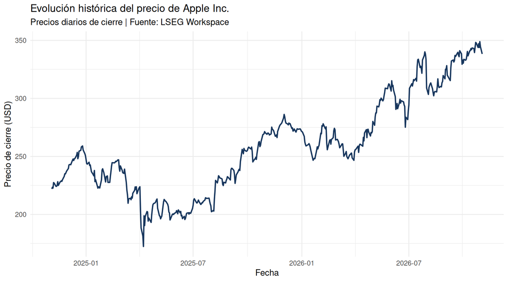

```r
# ============================================
# 4.2 EVOLUCIÓN DEL PRECIO DE AAPL
# ============================================

ggplot(apple, aes(x = Fecha, y = Precio)) +
  geom_line(color = "#17365D", linewidth = 0.8) +
  labs(
    title = "Evolución histórica del precio de Apple Inc.",
    subtitle = "Precios diarios de cierre | Fuente: LSEG Workspace",
    x = "Fecha",
    y = "Precio de cierre (USD)"
  ) +
  theme_minimal()
```

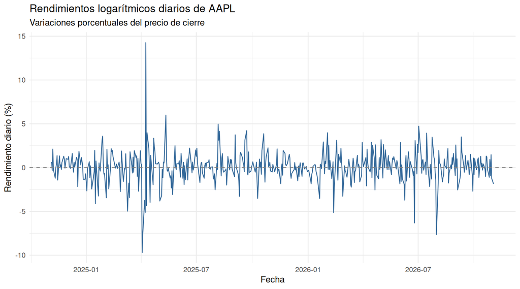

```r
# ============================================
# 4.3 RENDIMIENTOS LOGARÍTMICOS DIARIOS
# ============================================

ggplot(
  apple %>% filter(!is.na(Rendimiento)),
  aes(x = Fecha, y = Rendimiento)
) +
  geom_line(color = "#34699A", linewidth = 0.5) +
  geom_hline(
    yintercept = 0,
    linetype = "dashed",
    color = "gray50"
  ) +
  labs(
    title = "Rendimientos logarítmicos diarios de AAPL",
    subtitle = "Variaciones porcentuales del precio de cierre",
    x = "Fecha",
    y = "Rendimiento diario (%)"
  ) +
  theme_minimal()
```

```r
# ============================================
# 4.4 ESTADÍSTICA DESCRIPTIVA
# ============================================

rendimientos <- na.omit(apple$Rendimiento)

estadisticas <- data.frame(
  Indicador = c(
    "Número de rendimientos",
    "Rendimiento promedio diario (%)",
    "Volatilidad diaria (%)",
    "Volatilidad anualizada (%)",
    "Rendimiento mínimo (%)",
    "Rendimiento máximo (%)"
  ),
  Valor = c(
    length(rendimientos),
    mean(rendimientos),
    sd(rendimientos),
    sd(rendimientos) * sqrt(252),
    min(rendimientos),
    max(rendimientos)
  )
)

knitr::kable(
  estadisticas,
  digits = 4,
  caption = "Estadística descriptiva de rendimientos de AAPL"
)
```

Estadística descriptiva de rendimientos de AAPL

| Indicador | Valor |
| --- | --- |
| Número de rendimientos | 499.0000 |
| Rendimiento promedio diario (%) | 0.0844 |
| Volatilidad diaria (%) | 1.8013 |
| Volatilidad anualizada (%) | 28.5944 |
| Rendimiento mínimo (%) | -9.7013 |
| Rendimiento máximo (%) | 14.2617 |

# 5. Modelación de volatilidad mediante GARCH(1,1)

El modelo Generalized Autoregressive Conditional Heteroskedasticity (GARCH) permite estimar la volatilidad condicional de los rendimientos financieros, considerando que los periodos de alta y baja volatilidad tienden a agruparse.

Se utiliza una especificación GARCH(1,1), en la cual la varianza condicional depende de las innovaciones del periodo anterior y de la varianza condicional previamente estimada.

El objetivo es identificar la persistencia de la volatilidad de Apple Inc. y generar un pronóstico que posteriormente pueda incorporarse a la simulación Monte Carlo y a la valuación de la opción Call americana.

```r
# ============================================
# 5.1 ESTIMACIÓN DEL MODELO GARCH(1,1)
# ============================================

# Especificación del modelo
spec_garch <- ugarchspec(
  variance.model = list(
    model = "sGARCH",
    garchOrder = c(1, 1)
  ),
  mean.model = list(
    armaOrder = c(0, 0),
    include.mean = TRUE
  ),
  distribution.model = "std"
)

# Estimación utilizando rendimientos diarios
modelo_garch <- ugarchfit(
  spec = spec_garch,
  data = rendimientos,
  solver = "hybrid"
)

# Mostrar resultados del modelo
show(modelo_garch)
```

```
##
## *---------------------------------*
## *          GARCH Model Fit        *
## *---------------------------------*
##
## Conditional Variance Dynamics
## -----------------------------------
## GARCH Model  : sGARCH(1,1)
## Mean Model   : ARFIMA(0,0,0)
## Distribution : std
##
## Optimal Parameters
## ------------------------------------
##         Estimate  Std. Error  t value Pr(>|t|)
## mu       0.12937    0.057008   2.2693 0.023252
## omega    0.76280    0.495184   1.5404 0.123453
## alpha1   0.19151    0.102069   1.8763 0.060618
## beta1    0.61907    0.186981   3.3109 0.000930
## shape    3.21050    0.537913   5.9684 0.000000
##
## Robust Standard Errors:
##         Estimate  Std. Error  t value Pr(>|t|)
## mu       0.12937    0.057833   2.2369 0.025291
## omega    0.76280    0.534108   1.4282 0.153240
## alpha1   0.19151    0.114625   1.6708 0.094770
## beta1    0.61907    0.202504   3.0571 0.002235
## shape    3.21050    0.464363   6.9138 0.000000
##
## LogLikelihood : -915.1827
##
## Information Criteria
## ------------------------------------
##
## Akaike       3.6881
## Bayes        3.7303
## Shibata      3.6879
## Hannan-Quinn 3.7047
##
## Weighted Ljung-Box Test on Standardized Residuals
## ------------------------------------
```

[output cut: 40 more lines]

```
## Negative Sign Bias  0.8835 0.3774
## Positive Sign Bias  0.9604 0.3373
## Joint Effect        2.3342 0.5060
##
##
## Adjusted Pearson Goodness-of-Fit Test:
## ------------------------------------
##   group statistic p-value(g-1)
## 1    20     18.96       0.4597
## 2    30     25.43       0.6558
## 3    40     33.67       0.7114
## 4    50     50.20       0.4257
##
##
## Elapsed time : 0.102953
```

```r
# Tabla de parámetros estimados
parametros_garch <- as.data.frame(
  coef(modelo_garch)
)

colnames(parametros_garch) <- "Estimación"
parametros_garch$Parametro <- rownames(parametros_garch)

knitr::kable(
  parametros_garch[, c("Parametro", "Estimación")],
  digits = 6,
  caption = "Parámetros estimados del modelo GARCH(1,1)"
)
```

Parámetros estimados del modelo GARCH(1,1)

|  | Parametro | Estimación |
| --- | --- | --- |
| mu | mu | 0.129367 |
| omega | omega | 0.762803 |
| alpha1 | alpha1 | 0.191510 |
| beta1 | beta1 | 0.619067 |
| shape | shape | 3.210504 |

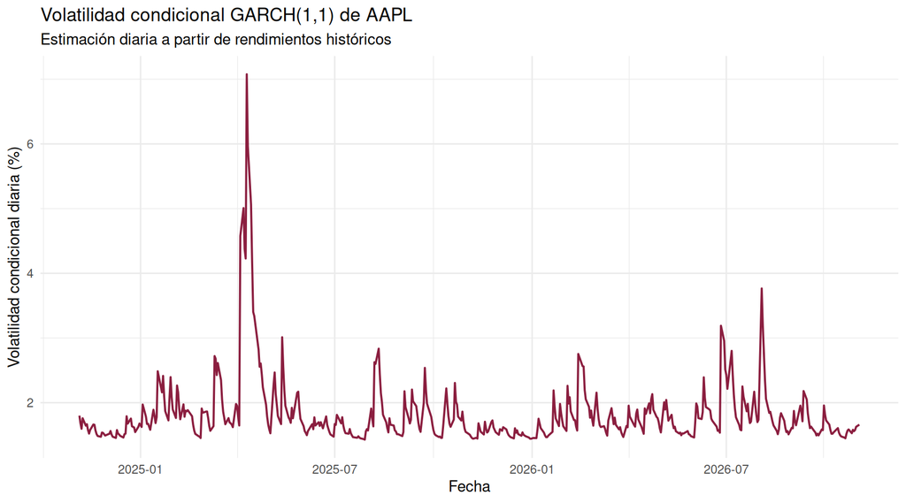

```r
# ============================================
# 5.2 VOLATILIDAD CONDICIONAL ESTIMADA
# ============================================

volatilidad_garch <- data.frame(
  Fecha = apple$Fecha[-1],
  Volatilidad = as.numeric(sigma(modelo_garch))
)

ggplot(
  volatilidad_garch,
  aes(x = Fecha, y = Volatilidad)
) +
  geom_line(
    color = "#8B1E3F",
    linewidth = 0.7
  ) +
  labs(
    title = "Volatilidad condicional GARCH(1,1) de AAPL",
    subtitle = "Estimación diaria a partir de rendimientos históricos",
    x = "Fecha",
    y = "Volatilidad condicional diaria (%)"
  ) +
  theme_minimal()
```

```r
# ============================================
# 5.3 PRONÓSTICO DE VOLATILIDAD
# ============================================

pronostico_garch <- ugarchforecast(
  modelo_garch,
  n.ahead = 10
)

vol_diaria <- as.numeric(
  sigma(pronostico_garch)
)

vol_anualizada <- vol_diaria * sqrt(252)

tabla_pronostico <- data.frame(
  Dia = 1:10,
  Volatilidad_Diaria = vol_diaria,
  Volatilidad_Anualizada = vol_anualizada
)

knitr::kable(
  tabla_pronostico,
  digits = 4,
  caption = "Pronóstico de volatilidad GARCH a 10 días bursátiles"
)
```

Pronóstico de volatilidad GARCH a 10 días bursátiles

| Dia | Volatilidad_Diaria | Volatilidad_Anualizada |
| --- | --- | --- |
| 1 | 1.7940 | 28.4785 |
| 2 | 1.8362 | 29.1483 |
| 3 | 1.8697 | 29.6802 |
| 4 | 1.8964 | 30.1044 |
| 5 | 1.9178 | 30.4439 |
| 6 | 1.9349 | 30.7164 |
| 7 | 1.9487 | 30.9354 |
| 8 | 1.9599 | 31.1119 |
| 9 | 1.9688 | 31.2542 |
| 10 | 1.9761 | 31.3690 |

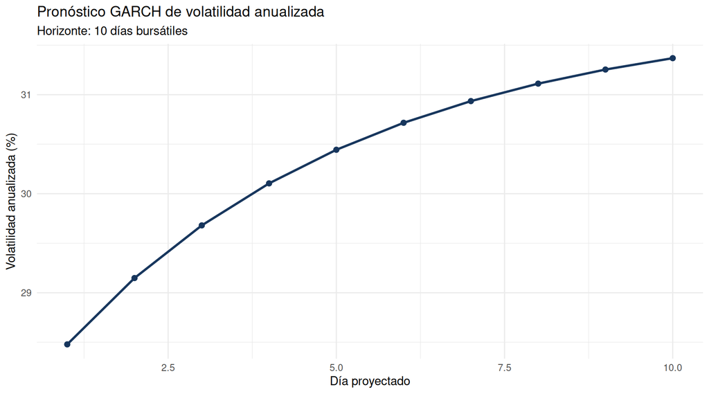

```r
ggplot(
  tabla_pronostico,
  aes(x = Dia, y = Volatilidad_Anualizada)
) +
  geom_line(
    color = "#17365D",
    linewidth = 1
  ) +
  geom_point(
    color = "#17365D",
    size = 2
  ) +
  labs(
    title = "Pronóstico GARCH de volatilidad anualizada",
    subtitle = "Horizonte: 10 días bursátiles",
    x = "Día proyectado",
    y = "Volatilidad anualizada (%)"
  ) +
  theme_minimal()
```

## 5.4 Persistencia y volatilidad de largo plazo

```r
# ============================================
# 5.4 PERSISTENCIA DEL MODELO GARCH(1,1)
# ============================================

coef_garch <- coef(modelo_garch)

persistencia <- unname(coef_garch["alpha1"] + coef_garch["beta1"])

# Varianza de largo plazo: omega / (1 - alpha - beta)
var_largo_plazo <- unname(coef_garch["omega"] / (1 - persistencia))
vol_largo_plazo_diaria <- sqrt(var_largo_plazo)
vol_largo_plazo_anual <- vol_largo_plazo_diaria * sqrt(252)

# Días para que una desviación de la varianza se reduzca a la mitad
vida_media <- log(0.5) / log(persistencia)

tabla_persistencia <- data.frame(
  Indicador = c(
    "Persistencia (alpha + beta)",
    "Volatilidad diaria de largo plazo (%)",
    "Volatilidad anualizada de largo plazo (%)",
    "Vida media de un choque de volatilidad (días)",
    "Grados de libertad de la distribución t"
  ),
  Valor = c(
    persistencia,
    vol_largo_plazo_diaria,
    vol_largo_plazo_anual,
    vida_media,
    unname(coef_garch["shape"])
  )
)

knitr::kable(
  tabla_persistencia,
  digits = 4,
  caption = "Persistencia y nivel de largo plazo de la volatilidad de AAPL"
)
```

Persistencia y nivel de largo plazo de la volatilidad de AAPL

| Indicador | Valor |
| --- | --- |
| Persistencia (alpha + beta) | 0.8106 |
| Volatilidad diaria de largo plazo (%) | 2.0067 |
| Volatilidad anualizada de largo plazo (%) | 31.8559 |
| Vida media de un choque de volatilidad (días) | 3.3006 |
| Grados de libertad de la distribución t | 3.2105 |

## 5.5 Interpretación del modelo GARCH

La suma de alpha y beta es de 0.8106, lo que indica una persistencia moderada: los choques de volatilidad de AAPL se disipan en pocos días, con una vida media de alrededor de 3.3 días. A partir de los parámetros estimados, la volatilidad de largo plazo de AAPL es de 31.86% anual.

Esto explica la forma del pronóstico de la sección 5.3: la volatilidad actual (28.48% anual) está por debajo de su nivel de largo plazo, por lo que el modelo proyecta que irá subiendo hasta 31.37% en el día 10.

El parámetro de forma de la distribución t (3.21) es bajo, lo que confirma que los rendimientos de AAPL tienen colas más pesadas que una distribución normal: los movimientos extremos, como el de 14.26% o el de -9.7% de la muestra, son más frecuentes de lo que supondría una normal.

# 6. Simulación Monte Carlo del precio de Apple Inc. (AAPL)

La simulación Monte Carlo permite proyectar diferentes trayectorias posibles del precio de una acción mediante la generación de escenarios aleatorios.

Para este análisis se utiliza el precio de cierre más reciente de Apple Inc. y la volatilidad condicional pronosticada mediante el modelo GARCH(1,1).

Se simulan 10,000 trayectorias durante un horizonte de 10 días bursátiles, equivalente aproximadamente a dos semanas de negociación. El objetivo es evaluar la distribución de posibles precios futuros de AAPL y sus implicaciones para la estrategia de opciones registrada en Investopedia.

La simulación emplea un movimiento browniano geométrico con volatilidad diaria variable estimada por GARCH. Los resultados representan escenarios probabilísticos sujetos a los supuestos del modelo, no predicciones exactas del precio.

```r
# ============================================
# 6.1 SIMULACIÓN MONTE CARLO CON GARCH
# ============================================

set.seed(123)

# Parámetros de la simulación
S0 <- tail(apple$Precio, 1)
n_simulaciones <- 10000
n_dias <- 10

# Rendimiento logarítmico promedio histórico
mu_diaria <- mean(rendimientos) / 100

# Volatilidad diaria proyectada por GARCH
# Convertimos de porcentaje a decimal
sigma_diaria <- as.numeric(
  sigma(pronostico_garch)
) / 100

stopifnot(
  length(sigma_diaria) >= n_dias,
  all(is.finite(sigma_diaria)),
  all(sigma_diaria > 0)
)

# Matriz para almacenar las trayectorias
precios_mc <- matrix(
  NA_real_,
  nrow = n_dias + 1,
  ncol = n_simulaciones
)

precios_mc[1, ] <- S0

# Simulación con movimiento browniano geométrico
for (t in 1:n_dias) {

  Z <- rnorm(n_simulaciones)

  precios_mc[t + 1, ] <- precios_mc[t, ] *
    exp(
      mu_diaria -
      0.5 * sigma_diaria[t]^2 +
      sigma_diaria[t] * Z
    )
}

# Precios al final del horizonte
precios_finales <- precios_mc[n_dias + 1, ]

cat("Precio inicial de AAPL:", round(S0, 2), "USD\n")
```

```
## Precio inicial de AAPL: 338.32 USD
```

```r
cat("Número de simulaciones:", n_simulaciones, "\n")
```

```
## Número de simulaciones: 10000
```

```r
cat("Horizonte:", n_dias, "días bursátiles\n")
```

```
## Horizonte: 10 días bursátiles
```

```r
cat(
  "Precio promedio simulado:",
  round(mean(precios_finales), 2),
  "USD\n"
)
```

```
## Precio promedio simulado: 341.26 USD
```

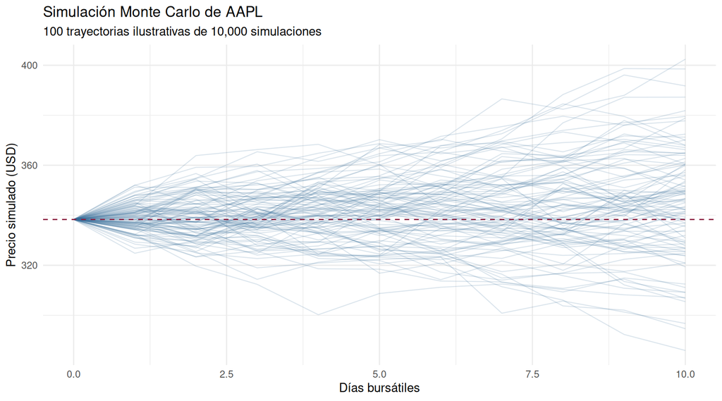

```r
# ============================================
# 6.2 TRAYECTORIAS SIMULADAS
# ============================================

trayectorias_grafica <- data.frame(
  Dia = rep(
    0:n_dias,
    times = 100
  ),
  Precio = as.vector(
    precios_mc[, 1:100]
  ),
  Simulacion = rep(
    1:100,
    each = n_dias + 1
  )
)

ggplot(
  trayectorias_grafica,
  aes(
    x = Dia,
    y = Precio,
    group = Simulacion
  )
) +
  geom_line(
    color = "#34699A",
    alpha = 0.18,
    linewidth = 0.4
  ) +
  geom_hline(
    yintercept = S0,
    color = "#8B1E3F",
    linetype = "dashed"
  ) +
  labs(
    title = "Simulación Monte Carlo de AAPL",
    subtitle = "100 trayectorias ilustrativas de 10,000 simulaciones",
    x = "Días bursátiles",
    y = "Precio simulado (USD)"
  ) +
  theme_minimal()
```

```r
# ============================================
# 6.3 DISTRIBUCIÓN DE PRECIOS FUTUROS
# ============================================

# Strike de la Call registrada en Investopedia
K <- 345

tabla_mc <- data.frame(
  Indicador = c(
    "Precio inicial (USD)",
    "Precio promedio proyectado (USD)",
    "Mediana proyectada (USD)",
    "Percentil 5 (USD)",
    "Percentil 95 (USD)",
    "Probabilidad de terminar arriba de 345 USD (%)",
    "Probabilidad de terminar debajo del precio inicial (%)"
  ),
  Valor = c(
    S0,
    mean(precios_finales),
    median(precios_finales),
    as.numeric(quantile(precios_finales, 0.05)),
    as.numeric(quantile(precios_finales, 0.95)),
    mean(precios_finales > K) * 100,
    mean(precios_finales < S0) * 100
  )
)

knitr::kable(
  tabla_mc,
  digits = 2,
  caption = "Resultados de Monte Carlo a 10 días bursátiles"
)
```

Resultados de Monte Carlo a 10 días bursátiles

| Indicador | Valor |
| --- | --- |
| Precio inicial (USD) | 338.32 |
| Precio promedio proyectado (USD) | 341.26 |
| Mediana proyectada (USD) | 340.42 |
| Percentil 5 (USD) | 308.47 |
| Percentil 95 (USD) | 376.58 |
| Probabilidad de terminar arriba de 345 USD (%) | 41.44 |
| Probabilidad de terminar debajo del precio inicial (%) | 45.81 |

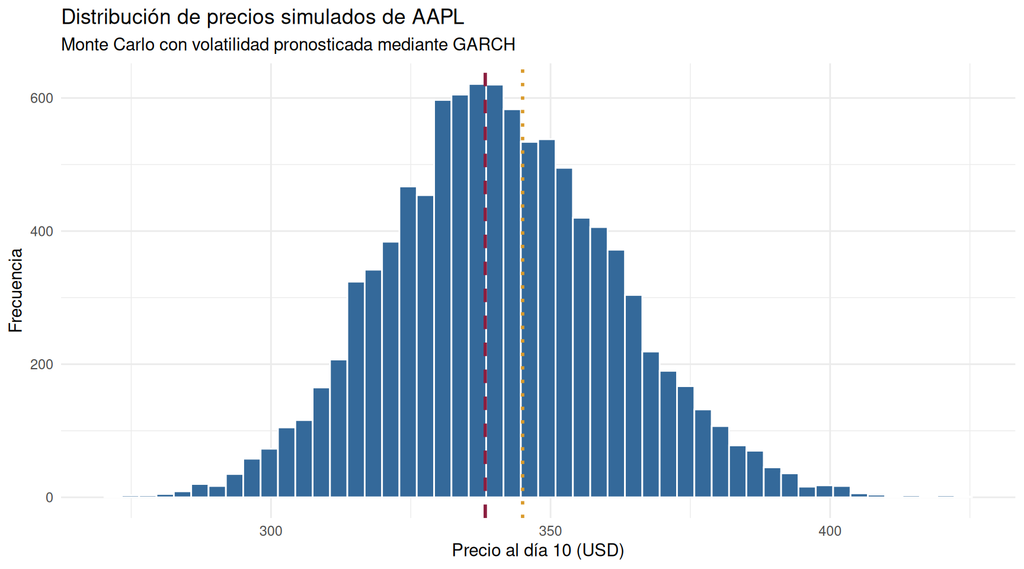

```r
# Histograma de precios finales
ggplot(
  data.frame(Precio = precios_finales),
  aes(x = Precio)
) +
  geom_histogram(
    bins = 50,
    fill = "#34699A",
    color = "white"
  ) +
  geom_vline(
    xintercept = S0,
    color = "#8B1E3F",
    linetype = "dashed",
    linewidth = 1
  ) +
  geom_vline(
    xintercept = K,
    color = "#D99A2B",
    linetype = "dotted",
    linewidth = 1
  ) +
  labs(
    title = "Distribución de precios simulados de AAPL",
    subtitle = "Monte Carlo con volatilidad pronosticada mediante GARCH",
    x = "Precio al día 10 (USD)",
    y = "Frecuencia"
  ) +
  theme_minimal()
```

## 6.4 Interpretación de los resultados

La simulación Monte Carlo, realizada mediante 10,000 trayectorias y utilizando la volatilidad pronosticada por GARCH(1,1), generó un precio promedio proyectado de USD 341.26 para Apple Inc. al finalizar un horizonte de 10 días bursátiles. Este resultado representa un incremento aproximado de 0.87% respecto al precio inicial de USD 338.32.

Los resultados muestran una dispersión considerable de posibles precios. El percentil 5 se ubicó en USD 308.47 y el percentil 95 en USD 376.58, lo que evidencia la incertidumbre asociada al comportamiento del subyacente.

En relación con nuestra estrategia de inversión, el modelo estima una probabilidad de 41.44% de que AAPL supere el precio de ejercicio de USD 345 al finalizar el horizonte simulado. Esto significa que, bajo los supuestos del modelo, aproximadamente cuatro de cada diez escenarios terminan por encima del strike.

Sin embargo, superar el strike no garantiza obtener una utilidad neta, debido a que la estrategia también debe recuperar la prima pagada de USD 13.50 por acción. Asimismo, la simulación corresponde a un horizonte de dos semanas y no al vencimiento de la opción, por lo que no representa directamente la probabilidad de rentabilidad final.

En consecuencia, los resultados muestran que la posición Call mantiene exposición a escenarios alcistas, pero también enfrenta riesgos asociados a la evolución del precio, la volatilidad y el tiempo restante al vencimiento.

# 7. Valuación mediante el modelo binomial CRR

El modelo binomial Cox-Ross-Rubinstein permite estimar el valor teórico de una opción mediante un proceso de movimientos ascendentes y descendentes del precio del subyacente.

En el caso de una opción americana, el modelo evalúa en cada nodo si resulta más conveniente ejercer anticipadamente o conservar la opción. Para la valuación se utiliza como referencia la volatilidad estimada mediante GARCH(1,1).

```r
# ============================================
# 7.1 ÁRBOL BINOMIAL AMERICANO - AAPL
# ============================================

# Datos de la posición
S0_bin <- as.numeric(tail(apple$Precio, 1))
K_bin <- 345
prima_compra <- 13.50
fecha_valuacion <- max(apple$Fecha)
fecha_vencimiento <- as.Date("2026-12-18")

# Supuesto de tasa libre de riesgo anual
r <- 0.04

# Apple no se modela aquí con dividendos discretos
# Usamos q = 0 como supuesto simplificador
q <- 0

# Volatilidad GARCH anualizada
# Se usa la volatilidad pronosticada del primer día
vol_bin <- as.numeric(sigma(pronostico_garch))[1] /
  100 * sqrt(252)

# Tiempo al vencimiento en años
T_bin <- as.numeric(
  fecha_vencimiento - fecha_valuacion
) / 365

stopifnot(T_bin > 0, vol_bin > 0)

# Número de pasos del árbol
N <- 200

dt <- T_bin / N

# Factores de subida y bajada
u <- exp(vol_bin * sqrt(dt))
d <- 1 / u

# Probabilidad neutral al riesgo
p <- (exp((r - q) * dt) - d) / (u - d)

stopifnot(p >= 0, p <= 1)

# Precios del subyacente al vencimiento
j <- 0:N

S_terminal <- S0_bin * u^j * d^(N - j)

# Payoff terminal de la Call
V <- pmax(S_terminal - K_bin, 0)

# Inducción hacia atrás
for (i in (N - 1):0) {

  V_continuacion <- exp(-r * dt) *
    ((1 - p) * V[1:(i + 1)] +
       p * V[2:(i + 2)])

  j <- 0:i
  S_nodos <- S0_bin * u^j * d^(i - j)

  V_ejercicio <- pmax(S_nodos - K_bin, 0)

  V <- pmax(V_continuacion, V_ejercicio)
}

precio_teorico_call <- V[1]

# Resultados
tabla_binomial <- data.frame(
  Indicador = c(
    "Precio actual de AAPL (USD)",
    "Strike (USD)",
    "Prima pagada (USD)",
    "Volatilidad GARCH anualizada (%)",
    "Tasa libre de riesgo supuesta (%)",
    "Días calendario al vencimiento",
    "Número de pasos",
    "Valor teórico Call americana (USD)",
    "Diferencia teórico vs. prima pagada (USD)"
  ),
  Valor = c(
    S0_bin,
    K_bin,
    prima_compra,
    vol_bin * 100,
    r * 100,
    as.numeric(fecha_vencimiento - fecha_valuacion),
    N,
    precio_teorico_call,
    precio_teorico_call - prima_compra
  )
)

knitr::kable(
  tabla_binomial,
  digits = 4,
  caption = "Valuación binomial CRR de la Call americana AAPL"
)
```

Valuación binomial CRR de la Call americana AAPL

| Indicador | Valor |
| --- | --- |
| Precio actual de AAPL (USD) | 338.3200 |
| Strike (USD) | 345.0000 |
| Prima pagada (USD) | 13.5000 |
| Volatilidad GARCH anualizada (%) | 28.4785 |
| Tasa libre de riesgo supuesta (%) | 4.0000 |
| Días calendario al vencimiento | 46.0000 |
| Número de pasos | 200.0000 |
| Valor teórico Call americana (USD) | 11.4221 |
| Diferencia teórico vs. prima pagada (USD) | -2.0779 |

## 7.1.1 Interpretación de la valuación binomial

Mediante el modelo binomial Cox-Ross-Rubinstein de 200 pasos, se obtuvo un valor teórico de USD 11.42 por acción para la opción Call americana de AAPL, con precio de ejercicio de USD 345 y vencimiento el 18 de diciembre de 2026.

La valuación utiliza una volatilidad anualizada de 28.48%, estimada mediante GARCH(1,1), y una tasa libre de riesgo supuesta de 4% anual.

Al comparar este resultado con la prima de adquisición de USD 13.50, se observa una diferencia negativa de USD 2.08 por acción, equivalente a aproximadamente 15.39% de la inversión inicial.

Esta diferencia no representa una pérdida realizada, sino una comparación entre el costo histórico de adquisición y el valor teórico actual. Asimismo, debe considerarse que la valuación depende de los supuestos de volatilidad, tasa de interés y dividendos.

El resultado permite relacionar la estimación de volatilidad mediante GARCH con la valuación de opciones, mostrando cómo los modelos cuantitativos pueden utilizarse para evaluar una posición real dentro de un simulador de inversiones.

## 7.2 Comparación con el precio de mercado

```r
# ============================================
# 7.2 COMPARACIÓN CON LA COTIZACIÓN OBSERVADA
# ============================================

# Función de valuación CRR para Call americana
valuar_call_crr <- function(S, K, r, q, sigma, T, N = 200) {

  dt <- T / N
  u <- exp(sigma * sqrt(dt))
  d <- 1 / u
  p <- (exp((r - q) * dt) - d) / (u - d)

  V <- pmax(S * u^(0:N) * d^(N:0) - K, 0)

  for (i in (N - 1):0) {
    V <- exp(-r * dt) * ((1 - p) * V[1:(i + 1)] + p * V[2:(i + 2)])
    V <- pmax(V, S * u^(0:i) * d^(i:0) - K)
  }

  V[1]
}

# Cotización observada de la Call en Investopedia
prima_mercado <- 11.10

# Volatilidad implícita en el precio de mercado
vol_implicita <- uniroot(
  function(s) valuar_call_crr(S0_bin, K_bin, r, q, s, T_bin, N) - prima_mercado,
  interval = c(0.05, 1)
)$root

tabla_mercado <- data.frame(
  Indicador = c(
    "Valor teórico CRR con volatilidad GARCH (USD)",
    "Cotización observada en Investopedia (USD)",
    "Diferencia modelo - mercado (USD)",
    "Volatilidad GARCH anualizada (%)",
    "Volatilidad implícita en la cotización (%)"
  ),
  Valor = c(
    precio_teorico_call,
    prima_mercado,
    precio_teorico_call - prima_mercado,
    vol_bin * 100,
    vol_implicita * 100
  )
)

knitr::kable(
  tabla_mercado,
  digits = 4,
  caption = "Valor teórico frente a la cotización de mercado"
)
```

Valor teórico frente a la cotización de mercado

| Indicador | Valor |
| --- | --- |
| Valor teórico CRR con volatilidad GARCH (USD) | 11.4221 |
| Cotización observada en Investopedia (USD) | 11.1000 |
| Diferencia modelo - mercado (USD) | 0.3221 |
| Volatilidad GARCH anualizada (%) | 28.4785 |
| Volatilidad implícita en la cotización (%) | 27.8019 |

## 7.3 Árbol de cuatro pasos: niveles de nodos

Para mostrar cómo se construye la valuación, se presenta un árbol de cuatro pasos con los mismos datos. Cada nodo indica el precio de AAPL, el valor de la Call y si conviene ejercerla anticipadamente.

```r
# ============================================
# 7.3 ÁRBOL DE CUATRO PASOS
# ============================================

N_vis <- 4
dt_vis <- T_bin / N_vis
u_vis <- exp(vol_bin * sqrt(dt_vis))
d_vis <- 1 / u_vis
p_vis <- (exp((r - q) * dt_vis) - d_vis) / (u_vis - d_vis)

# Precios por paso
precios_vis <- lapply(0:N_vis, function(i) S0_bin * u_vis^(0:i) * d_vis^(i:0))

# Valores por paso (inducción hacia atrás)
valores_vis <- vector("list", N_vis + 1)
ejercicio_vis <- vector("list", N_vis + 1)
valores_vis[[N_vis + 1]] <- pmax(precios_vis[[N_vis + 1]] - K_bin, 0)
ejercicio_vis[[N_vis + 1]] <- rep(FALSE, N_vis + 1)

for (i in (N_vis - 1):0) {
  v_cont <- exp(-r * dt_vis) *
    ((1 - p_vis) * valores_vis[[i + 2]][1:(i + 1)] +
       p_vis * valores_vis[[i + 2]][2:(i + 2)])
  v_ejer <- pmax(precios_vis[[i + 1]] - K_bin, 0)
  ejercicio_vis[[i + 1]] <- v_ejer > v_cont
  valores_vis[[i + 1]] <- pmax(v_cont, v_ejer)
}

nodos_vis <- do.call(rbind, lapply(0:N_vis, function(i) {
  data.frame(
    Paso = i,
    Subidas = 0:i,
    Precio_AAPL = precios_vis[[i + 1]],
    Valor_Call = valores_vis[[i + 1]],
    Ejercicio_anticipado = ejercicio_vis[[i + 1]]
  )
}))

knitr::kable(
  nodos_vis,
  digits = 2,
  caption = "Nodos del árbol CRR americano de cuatro pasos"
)
```

Nodos del árbol CRR americano de cuatro pasos

| Paso | Subidas | Precio_AAPL | Valor_Call | Ejercicio_anticipado |
| --- | --- | --- | --- | --- |
| 0 | 0 | 338.32 | 11.58 | FALSE |
| 1 | 0 | 321.64 | 3.65 | FALSE |
| 1 | 1 | 355.86 | 19.55 | FALSE |
| 2 | 0 | 305.79 | 0.00 | FALSE |
| 2 | 1 | 338.32 | 7.30 | FALSE |
| 2 | 2 | 374.31 | 31.85 | FALSE |
| 3 | 0 | 290.71 | 0.00 | FALSE |
| 3 | 1 | 321.64 | 0.00 | FALSE |
| 3 | 2 | 355.86 | 14.63 | FALSE |
| 3 | 3 | 393.72 | 49.16 | FALSE |
| 4 | 0 | 276.38 | 0.00 | FALSE |
| 4 | 1 | 305.79 | 0.00 | FALSE |
| 4 | 2 | 338.32 | 0.00 | FALSE |
| 4 | 3 | 374.31 | 29.31 | FALSE |
| 4 | 4 | 414.13 | 69.13 | FALSE |

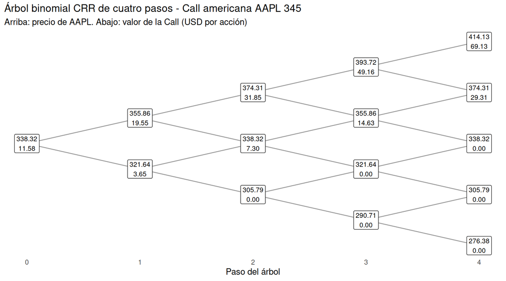

```r
# Gráfica del árbol
nodos_vis$x <- nodos_vis$Paso
nodos_vis$y <- 2 * nodos_vis$Subidas - nodos_vis$Paso
nodos_vis$Etiqueta <- sprintf("%.2f\n%.2f", nodos_vis$Precio_AAPL, nodos_vis$Valor_Call)

ramas_vis <- do.call(rbind, lapply(0:(N_vis - 1), function(i) {
  j <- 0:i
  rbind(
    data.frame(x = i, y = 2 * j - i, xend = i + 1, yend = 2 * (j + 1) - (i + 1)),
    data.frame(x = i, y = 2 * j - i, xend = i + 1, yend = 2 * j - (i + 1))
  )
}))

ggplot() +
  geom_segment(
    data = ramas_vis,
    aes(x = x, y = y, xend = xend, yend = yend),
    color = "gray60"
  ) +
  geom_label(
    data = nodos_vis,
    aes(x = x, y = y, label = Etiqueta),
    size = 3,
    fill = "white"
  ) +
  labs(
    title = "Árbol binomial CRR de cuatro pasos - Call americana AAPL 345",
    subtitle = "Arriba: precio de AAPL. Abajo: valor de la Call (USD por acción)",
    x = "Paso del árbol",
    y = NULL
  ) +
  theme_minimal() +
  theme(axis.text.y = element_blank(), panel.grid = element_blank())
```

El nodo inicial muestra AAPL en USD 338.32 y la Call valuada en USD 11.58 con solo cuatro pasos. Los nodos superiores representan escenarios de subida y los inferiores de bajada; al vencimiento la Call solo tiene valor en los nodos donde AAPL supera USD 345. En ningún nodo conviene ejercer antes del vencimiento, porque sin dividendos el valor de conservar la Call siempre es mayor que su valor intrínseco. Con cuatro pasos el valor es una aproximación; el árbol de 200 pasos de la sección 7.1 da el valor más preciso.

# 8. Evaluación de rentabilidad de la estrategia

En esta sección se analiza la rentabilidad observada de la posición Call de Apple Inc. registrada en Investopedia y se compara con la valuación teórica obtenida mediante el árbol binomial CRR.

Se distingue entre los resultados observados en el simulador, las estimaciones del modelo y los escenarios futuros, con el propósito de evitar interpretar resultados hipotéticos como ganancias o pérdidas realizadas.

## 8.0 Posición de AAPL en el portafolio de Investopedia

El historial de operaciones de Investopedia (descargado el 2 de noviembre de 2026) muestra que la Call 345 no es la única posición del equipo sobre AAPL. El 30 de septiembre se compraron 100 acciones de AAPL junto con una Put 330 con vencimiento al 7 de octubre como protección (Protective Put de la Tarea 2), y el 27 de octubre se agregó la Call 345 de diciembre. Para medir la rentabilidad de la estrategia completa, cada posición se valúa con el último cierre de LSEG.

```r
# ============================================
# 8.0 POSICIÓN TOTAL DE AAPL EN INVESTOPEDIA
# ============================================

# Operaciones registradas en el historial de Investopedia (trade history)
operaciones <- data.frame(
  Fecha = as.Date(c("2026-09-30", "2026-09-30", "2026-10-27")),
  Instrumento = c("Acciones AAPL", "Put AAPL 330 (vence 07-oct-2026)",
                  "Call AAPL 345 (vence 18-dic-2026)"),
  Cantidad = c(100, 1, 1),
  Precio_compra = c(330.80, 3.20, 13.50),
  Unidades = c(100, 100, 100)
)

# Cierre de AAPL el día de vencimiento de la Put (dato de LSEG)
cierre_venc_put <- apple$Precio[apple$Fecha == as.Date("2026-10-07")]

# Valor actual de cada posición
operaciones$Precio_actual <- c(
  S0,                                  # último cierre de AAPL en LSEG
  max(330 - cierre_venc_put, 0),       # la Put ya venció
  11.10                                # cotización de la Call en Investopedia
)

operaciones$Costo_USD <- operaciones$Cantidad * operaciones$Precio_compra *
  ifelse(operaciones$Instrumento == "Acciones AAPL", 1, operaciones$Unidades)
operaciones$Valor_actual_USD <- operaciones$Cantidad * operaciones$Precio_actual *
  ifelse(operaciones$Instrumento == "Acciones AAPL", 1, operaciones$Unidades)
operaciones$PnL_USD <- operaciones$Valor_actual_USD - operaciones$Costo_USD
operaciones$Rentabilidad_pct <- 100 * operaciones$PnL_USD / operaciones$Costo_USD

total_posicion <- data.frame(
  Fecha = NA, Instrumento = "Total posición AAPL", Cantidad = NA,
  Precio_compra = NA, Unidades = NA, Precio_actual = NA,
  Costo_USD = sum(operaciones$Costo_USD),
  Valor_actual_USD = sum(operaciones$Valor_actual_USD),
  PnL_USD = sum(operaciones$PnL_USD),
  Rentabilidad_pct = 100 * sum(operaciones$PnL_USD) / sum(operaciones$Costo_USD)
)

knitr::kable(
  rbind(operaciones, total_posicion)[, c("Fecha", "Instrumento", "Cantidad",
    "Precio_compra", "Precio_actual", "Costo_USD", "Valor_actual_USD",
    "PnL_USD", "Rentabilidad_pct")],
  digits = 2,
  caption = "Rentabilidad de la posición total de AAPL en Investopedia"
)
```

Rentabilidad de la posición total de AAPL en Investopedia

| Fecha | Instrumento | Cantidad | Precio_compra | Precio_actual | Costo_USD | Valor_actual_USD | PnL_USD | Rentabilidad_pct |
| --- | --- | --- | --- | --- | --- | --- | --- | --- |
| 2026-09-30 | Acciones AAPL | 100 | 330.8 | 338.32 | 33080 | 33832 | 752 | 2.27 |
| 2026-09-30 | Put AAPL 330 (vence 07-oct-2026) | 1 | 3.2 | 0.00 | 320 | 0 | -320 | -100.00 |
| 2026-10-27 | Call AAPL 345 (vence 18-dic-2026) | 1 | 13.5 | 11.10 | 1350 | 1110 | -240 | -17.78 |
| NA | Total posición AAPL | NA | NA | NA | 34750 | 34942 | 192 | 0.55 |

La posición completa de AAPL en Investopedia tiene una ganancia de USD 192, equivalente a 0.55% sobre el capital invertido. Las 100 acciones compradas a USD 330.80 valen hoy USD 338.32 por acción y aportan una ganancia de USD 752, suficiente para compensar la Put de protección, que venció sin valor el 7 de octubre (AAPL cerró en USD 336.67), y la pérdida no realizada de la Call 345. Es decir, la estrategia de cobertura cumplió su función: el costo de la protección y de la Call se financia con la ganancia del subyacente.

```r
# ============================================
# 8.1 RENTABILIDAD OBSERVADA Y TEÓRICA
# ============================================

# Datos de la operación en Investopedia
contratos <- 1
multiplicador <- 100
prima_inicial <- 13.50

# Cotización observada en la captura de Investopedia
prima_observada <- 11.10

# Inversión inicial
inversion_inicial <- contratos *
  multiplicador * prima_inicial

# Valor observado de la posición
valor_observado <- contratos *
  multiplicador * prima_observada

# Resultado observado
pnl_observado <- valor_observado - inversion_inicial

rentabilidad_observada <- 100 *
  pnl_observado / inversion_inicial

# Valor estimado por el árbol binomial
valor_teorico <- contratos *
  multiplicador * precio_teorico_call

pnl_teorico <- valor_teorico - inversion_inicial

rentabilidad_teorica <- 100 *
  pnl_teorico / inversion_inicial

tabla_rentabilidad <- data.frame(
  Escenario = c(
    "Compra inicial",
    "Valor observado en Investopedia",
    "Valor teórico binomial"
  ),
  Valor_USD = c(
    inversion_inicial,
    valor_observado,
    valor_teorico
  ),
  PnL_USD = c(
    0,
    pnl_observado,
    pnl_teorico
  ),
  Rentabilidad_Porcentaje = c(
    0,
    rentabilidad_observada,
    rentabilidad_teorica
  )
)

knitr::kable(
  tabla_rentabilidad,
  digits = 2,
  caption = "Comparación de rentabilidad observada y teórica"
)
```

Comparación de rentabilidad observada y teórica

| Escenario | Valor_USD | PnL_USD | Rentabilidad_Porcentaje |
| --- | --- | --- | --- |
| Compra inicial | 1350.00 | 0.00 | 0.00 |
| Valor observado en Investopedia | 1110.00 | -240.00 | -17.78 |
| Valor teórico binomial | 1142.21 | -207.79 | -15.39 |

```r
# ============================================
# 8.2 VALUACIÓN BINOMIAL PARA ESCENARIOS
# ============================================

# Función de valuación de Call americana
call_americana_crr <- function(
    S, K, r, q, sigma, T, N = 100) {

  if (T <= 0) {
    return(pmax(S - K, 0))
  }

  dt <- T / N
  u <- exp(sigma * sqrt(dt))
  d <- 1 / u

  p <- (exp((r - q) * dt) - d) / (u - d)

  if (p < 0 || p > 1) {
    stop("Probabilidad neutral al riesgo inválida")
  }

  j <- 0:N

  S_terminal <- S * u^j * d^(N - j)
  V <- pmax(S_terminal - K, 0)

  for (i in (N - 1):0) {

    V_cont <- exp(-r * dt) *
      ((1 - p) * V[1:(i + 1)] +
         p * V[2:(i + 2)])

    j <- 0:i
    S_nodos <- S * u^j * d^(i - j)

    V <- pmax(
      V_cont,
      pmax(S_nodos - K, 0)
    )
  }

  return(V[1])
}

# Horizonte de 10 días bursátiles
# Aproximación: 14 días calendario
fecha_futura <- fecha_valuacion + 14

T_restante <- as.numeric(
  fecha_vencimiento - fecha_futura
) / 365

stopifnot(T_restante > 0)

# Para evitar cálculos excesivos, valoramos
# una muestra reproducible de 1,000 escenarios
set.seed(456)

indices <- sample(
  seq_along(precios_finales),
  size = 1000
)

precios_muestra <- precios_finales[indices]

# Supuesto: volatilidad constante en el
# horizonte restante, usando pronóstico GARCH día 10
sigma_futura <- tail(sigma_diaria, 1) * sqrt(252)

valores_call_futuros <- vapply(
  precios_muestra,
  function(S) {
    call_americana_crr(
      S = S,
      K = K_bin,
      r = r,
      q = q,
      sigma = sigma_futura,
      T = T_restante,
      N = 100
    )
  },
  numeric(1)
)

# Rentabilidad de cada escenario
pnl_futuro <- (
  valores_call_futuros - prima_inicial
) * multiplicador * contratos

rentabilidad_futura <- 100 *
  pnl_futuro / inversion_inicial

tabla_proyeccion <- data.frame(
  Indicador = c(
    "Valor promedio proyectado de la Call (USD)",
    "PnL promedio proyectado (USD)",
    "Rentabilidad promedio proyectada (%)",
    "Probabilidad de rentabilidad positiva (%)",
    "Percentil 5 del PnL (USD)",
    "Percentil 95 del PnL (USD)"
  ),
  Valor = c(
    mean(valores_call_futuros),
    mean(pnl_futuro),
    mean(rentabilidad_futura),
    mean(rentabilidad_futura > 0) * 100,
    as.numeric(quantile(pnl_futuro, 0.05)),
    as.numeric(quantile(pnl_futuro, 0.95))
  )
)

knitr::kable(
  tabla_proyeccion,
  digits = 2,
  caption = "Proyección de rentabilidad de la Call a dos semanas"
)
```

Proyección de rentabilidad de la Call a dos semanas

| Indicador | Valor |
| --- | --- |
| Valor promedio proyectado de la Call (USD) | 14.09 |
| PnL promedio proyectado (USD) | 58.59 |
| Rentabilidad promedio proyectada (%) | 4.34 |
| Probabilidad de rentabilidad positiva (%) | 41.70 |
| Percentil 5 del PnL (USD) | -1163.73 |
| Percentil 95 del PnL (USD) | 2250.85 |

## 8.2.1 Interpretación de la rentabilidad proyectada

La proyección de rentabilidad a dos semanas, obtenida mediante la integración de Monte Carlo, GARCH(1,1) y el modelo binomial CRR, estima un valor promedio de USD 14.09 por acción para la opción Call de AAPL.

Considerando la prima de adquisición de USD 13.50, el modelo genera una ganancia promedio proyectada de USD 58.59 por contrato, equivalente a una rentabilidad de 4.34% respecto a la inversión inicial de USD 1,350.

No obstante, la probabilidad estimada de obtener una rentabilidad positiva es de 41.70%, lo que indica que la mayoría de los escenarios simulados no permite recuperar completamente la prima de adquisición.

Asimismo, los percentiles 5 y 95 del resultado proyectado se ubican en −USD 1,163.73 y +USD 2,250.85, respectivamente, lo que evidencia una dispersión significativa en los posibles resultados.

Estos hallazgos muestran que una rentabilidad esperada positiva no implica necesariamente una alta probabilidad de obtener ganancias. La posición presenta un perfil asimétrico, donde determinados escenarios de apreciación del subyacente pueden generar utilidades relevantes, mientras que los escenarios desfavorables ocasionan pérdidas sobre la prima invertida.

Los resultados dependen de los supuestos de volatilidad, rendimiento esperado, tasa de interés y tiempo restante al vencimiento. Por lo tanto, deben interpretarse como estimaciones condicionadas al modelo y no como resultados garantizados.

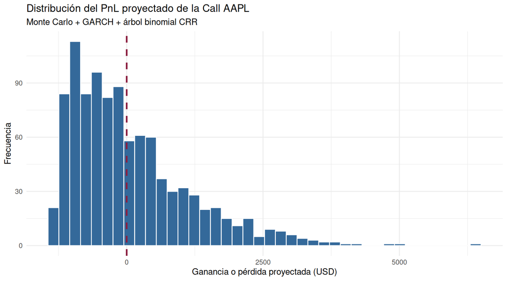

```r
# ============================================
# 8.3 DISTRIBUCIÓN DEL PNL PROYECTADO
# ============================================

ggplot(
  data.frame(PnL = pnl_futuro),
  aes(x = PnL)
) +
  geom_histogram(
    bins = 40,
    fill = "#34699A",
    color = "white"
  ) +
  geom_vline(
    xintercept = 0,
    color = "#8B1E3F",
    linetype = "dashed",
    linewidth = 1
  ) +
  labs(
    title = "Distribución del PnL proyectado de la Call AAPL",
    subtitle = "Monte Carlo + GARCH + árbol binomial CRR",
    x = "Ganancia o pérdida proyectada (USD)",
    y = "Frecuencia"
  ) +
  theme_minimal()
```

## 8.3.1 Interpretación de la distribución de ganancias y pérdidas

La distribución del PnL proyectado muestra una asimetría positiva, caracterizada por una mayor concentración de escenarios con pérdidas y una cola extendida hacia resultados favorables.

La probabilidad estimada de obtener una rentabilidad positiva es de 41.70%, mientras que la ganancia promedio proyectada asciende a USD 58.59 por contrato.

Este comportamiento refleja el perfil asimétrico de una posición larga en opciones Call. Aunque una proporción importante de escenarios presenta pérdidas respecto a la prima de adquisición, determinados movimientos alcistas del subyacente pueden generar ganancias de mayor magnitud.

Por lo tanto, el análisis evidencia la importancia de evaluar conjuntamente la rentabilidad esperada, la probabilidad de obtener ganancias y la dispersión de los resultados, en lugar de tomar decisiones únicamente con base en el rendimiento promedio.

## 8.4 Efecto de la volatilidad usada en la revaluación

En la proyección de la sección 8.2, la Call se revalúa dentro de dos semanas con la volatilidad GARCH del día 10 (31.37%), mientras que hoy se valúa con la del día 1 (28.48%). Como una mayor volatilidad aumenta el valor de una opción, parte del resultado proyectado proviene de ese aumento. Para medirlo, se repite la proyección con la misma volatilidad de hoy.

```r
# ============================================
# 8.4 SENSIBILIDAD A LA VOLATILIDAD
# ============================================

valores_call_constante <- vapply(
  precios_muestra,
  function(S) {
    call_americana_crr(
      S = S, K = K_bin, r = r, q = q,
      sigma = vol_bin, T = T_restante, N = 100
    )
  },
  numeric(1)
)

pnl_constante <- (valores_call_constante - prima_inicial) *
  multiplicador * contratos

tabla_sensibilidad_vol <- data.frame(
  Indicador = c(
    "Volatilidad usada en la revaluación (%)",
    "Valor promedio de la Call (USD)",
    "PnL promedio (USD)",
    "Probabilidad de rentabilidad positiva (%)",
    "Percentil 5 del PnL (USD)",
    "Percentil 95 del PnL (USD)"
  ),
  GARCH_dia_10 = c(
    sigma_futura * 100,
    mean(valores_call_futuros),
    mean(pnl_futuro),
    mean(pnl_futuro > 0) * 100,
    as.numeric(quantile(pnl_futuro, 0.05)),
    as.numeric(quantile(pnl_futuro, 0.95))
  ),
  Volatilidad_constante = c(
    vol_bin * 100,
    mean(valores_call_constante),
    mean(pnl_constante),
    mean(pnl_constante > 0) * 100,
    as.numeric(quantile(pnl_constante, 0.05)),
    as.numeric(quantile(pnl_constante, 0.95))
  )
)

knitr::kable(
  tabla_sensibilidad_vol,
  digits = 2,
  caption = "Proyección a dos semanas según la volatilidad usada"
)
```

Proyección a dos semanas según la volatilidad usada

| Indicador | GARCH_dia_10 | Volatilidad_constante |
| --- | --- | --- |
| Volatilidad usada en la revaluación (%) | 31.37 | 28.48 |
| Valor promedio de la Call (USD) | 14.09 | 13.12 |
| PnL promedio (USD) | 58.59 | -37.57 |
| Probabilidad de rentabilidad positiva (%) | 41.70 | 38.00 |
| Percentil 5 del PnL (USD) | -1163.73 | -1215.37 |
| Percentil 95 del PnL (USD) | 2250.85 | 2179.23 |

Con la volatilidad constante de 28.48%, el PnL promedio proyectado pasa de USD 58.59 a USD -37.57 y la probabilidad de ganancia baja a 38%. Es decir, la ganancia promedio de la sección 8.2 depende de que la volatilidad efectivamente suba como pronostica el GARCH. Si la volatilidad se mantiene, el paso del tiempo pesa más que la subida esperada de AAPL y la posición tiende a perder valor. Este resultado nos lleva a la propuesta de la siguiente sección.

# 9. Hallazgos y propuestas

## 9.1 Precio que necesita AAPL en dos semanas

```r
# ============================================
# 9.1 PRECIO DE EQUILIBRIO A DOS SEMANAS
# ============================================

# Precio de AAPL con el que la Call valdría la prima pagada
# dentro de dos semanas, con volatilidad constante
precio_equilibrio_2s <- uniroot(
  function(S) {
    call_americana_crr(
      S = S, K = K_bin, r = r, q = q,
      sigma = vol_bin, T = T_restante, N = 100
    ) - prima_inicial
  },
  interval = c(K_bin * 0.8, K_bin * 1.2)
)$root

tabla_equilibrio <- data.frame(
  Indicador = c(
    "Precio actual de AAPL (USD)",
    "Precio necesario en dos semanas (USD)",
    "Subida necesaria (%)",
    "Probabilidad Monte Carlo de alcanzarlo (%)"
  ),
  Valor = c(
    S0_bin,
    precio_equilibrio_2s,
    100 * (precio_equilibrio_2s / S0_bin - 1),
    100 * mean(precios_finales > precio_equilibrio_2s)
  )
)

knitr::kable(
  tabla_equilibrio,
  digits = 2,
  caption = "Precio de equilibrio de la Call a dos semanas"
)
```

Precio de equilibrio de la Call a dos semanas

| Indicador | Valor |
| --- | --- |
| Precio actual de AAPL (USD) | 338.32 |
| Precio necesario en dos semanas (USD) | 347.33 |
| Subida necesaria (%) | 2.66 |
| Probabilidad Monte Carlo de alcanzarlo (%) | 37.20 |

Para recuperar la prima de USD 13.50 en dos semanas, AAPL tendría que subir de USD 338.32 a cerca de USD 347.33, un avance de 2.66%. Según la simulación Monte Carlo, esto ocurre en 37.2% de los escenarios.

## 9.2 Propuesta: convertir la Call en un Bull Call Spread

Para mejorar el perfil de la posición proponemos vender una Call de AAPL con strike USD 355 y el mismo vencimiento del 18 de diciembre, manteniendo la Call 345 comprada. Así se forma un Bull Call Spread 345/355, la misma estructura que el equipo usó en las tareas anteriores. La prima recibida reduce el costo neto de la posición y el punto de equilibrio, a cambio de limitar la ganancia máxima a la diferencia entre strikes.

El precio de la Call 355 se estima con el mismo árbol CRR y la volatilidad GARCH. Al ejecutar la venta en Investopedia, `prima_venta_355` debe sustituirse por el Bid observado.

```r
# ============================================
# 9.2 PROPUESTA: BULL CALL SPREAD 345/355
# ============================================

K_venta <- 355

# Prima estimada de la Call 355 (sustituir por el Bid real al ejecutar)
prima_venta_355 <- call_americana_crr(
  S = S0_bin, K = K_venta, r = r, q = q,
  sigma = vol_bin, T = T_bin, N = 200
)

costo_neto_spread <- prima_inicial - prima_venta_355
equilibrio_spread <- K_bin + costo_neto_spread
ganancia_max_spread <- (K_venta - K_bin - costo_neto_spread) * multiplicador * contratos
perdida_max_spread <- costo_neto_spread * multiplicador * contratos

# Extensión del Monte Carlo hasta el vencimiento:
# a partir del día 10 se usa la volatilidad de largo plazo del GARCH
set.seed(789)
n_dias_rest <- round(T_restante * 252)
sigma_lp <- vol_largo_plazo_diaria / 100
precios_venc_mc <- precios_finales
for (t in 1:n_dias_rest) {
  precios_venc_mc <- precios_venc_mc *
    exp(mu_diaria - 0.5 * sigma_lp^2 + sigma_lp * rnorm(length(precios_venc_mc)))
}

pnl_call_venc <- (pmax(precios_venc_mc - K_bin, 0) - prima_inicial) *
  multiplicador * contratos
pnl_spread_venc <- (pmax(precios_venc_mc - K_bin, 0) -
  pmax(precios_venc_mc - K_venta, 0) - costo_neto_spread) *
  multiplicador * contratos

tabla_propuesta <- data.frame(
  Indicador = c(
    "Costo neto por acción (USD)",
    "Punto de equilibrio al vencimiento (USD)",
    "Pérdida máxima (USD)",
    "Ganancia máxima (USD)",
    "Probabilidad de ganancia al vencimiento (%)",
    "PnL promedio al vencimiento (USD)",
    "Percentil 5 del PnL al vencimiento (USD)",
    "Percentil 95 del PnL al vencimiento (USD)"
  ),
  Call_345_sola = c(
    prima_inicial,
    K_bin + prima_inicial,
    prima_inicial * multiplicador * contratos,
    NA,
    mean(pnl_call_venc > 0) * 100,
    mean(pnl_call_venc),
    as.numeric(quantile(pnl_call_venc, 0.05)),
    as.numeric(quantile(pnl_call_venc, 0.95))
  ),
  Bull_Call_Spread_345_355 = c(
    costo_neto_spread,
    equilibrio_spread,
    perdida_max_spread,
    ganancia_max_spread,
    mean(pnl_spread_venc > 0) * 100,
    mean(pnl_spread_venc),
    as.numeric(quantile(pnl_spread_venc, 0.05)),
    as.numeric(quantile(pnl_spread_venc, 0.95))
  )
)

knitr::kable(
  tabla_propuesta,
  digits = 2,
  caption = "Call 345 sola frente a Bull Call Spread 345/355 al 18-dic-2026 (NA = ganancia ilimitada)"
)
```

Call 345 sola frente a Bull Call Spread 345/355 al 18-dic-2026 (NA = ganancia ilimitada)

| Indicador | Call_345_sola | Bull_Call_Spread_345_355 |
| --- | --- | --- |
| Costo neto por acción (USD) | 13.50 | 5.75 |
| Punto de equilibrio al vencimiento (USD) | 358.50 | 350.75 |
| Pérdida máxima (USD) | 1350.00 | 574.99 |
| Ganancia máxima (USD) | NA | 425.01 |
| Probabilidad de ganancia al vencimiento (%) | 37.21 | 44.80 |
| PnL promedio al vencimiento (USD) | 335.97 | -118.74 |
| Percentil 5 del PnL al vencimiento (USD) | -1350.00 | -574.99 |
| Percentil 95 del PnL al vencimiento (USD) | 5643.47 | 425.01 |

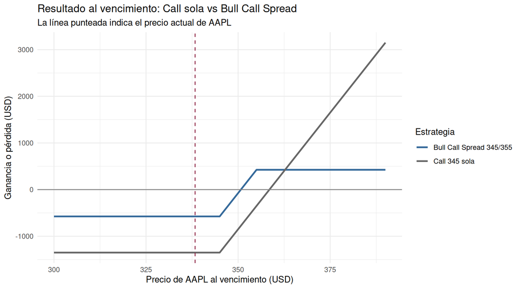

```r
# Resultado al vencimiento de ambas estrategias
precios_venc <- seq(300, 390, by = 0.5)

payoff_estrategias <- data.frame(
  Precio = rep(precios_venc, 2),
  Estrategia = rep(c("Call 345 sola", "Bull Call Spread 345/355"), each = length(precios_venc)),
  PnL = c(
    (pmax(precios_venc - K_bin, 0) - prima_inicial) * multiplicador,
    (pmax(precios_venc - K_bin, 0) - pmax(precios_venc - K_venta, 0) - costo_neto_spread) * multiplicador
  )
)

ggplot(payoff_estrategias, aes(x = Precio, y = PnL, color = Estrategia)) +
  geom_line(linewidth = 1) +
  geom_hline(yintercept = 0, color = "gray50") +
  geom_vline(xintercept = S0_bin, linetype = "dashed", color = "#8B1E3F") +
  scale_color_manual(values = c("#34699A", "gray40")) +
  labs(
    title = "Resultado al vencimiento: Call sola vs Bull Call Spread",
    subtitle = "La línea punteada indica el precio actual de AAPL",
    x = "Precio de AAPL al vencimiento (USD)",
    y = "Ganancia o pérdida (USD)"
  ) +
  theme_minimal()
```

## 9.3 Interpretación de la propuesta

Vender la Call 355 a un precio estimado de USD 7.75 reduce el costo neto de la posición de USD 13.50 a USD 5.75 por acción. El punto de equilibrio al vencimiento baja de USD 358.50 a USD 350.75, y la pérdida máxima pasa de USD 1,350 a USD 574.99.

Para evaluar la propuesta hasta el vencimiento, las 10,000 trayectorias de Monte Carlo se extienden del día 10 al 18 de diciembre usando la volatilidad de largo plazo del GARCH (31.86% anual), que es el nivel al que el modelo indica que regresa la volatilidad. Con esos escenarios, la probabilidad de terminar con ganancia es de 44.8% con el spread, frente a 37.2% con la Call sola. En los escenarios desfavorables el spread también pierde menos: su percentil 5 es de USD -574.99, contra USD -1350 de la Call sola.

A cambio, el spread renuncia a las ganancias de una subida fuerte: su ganancia máxima queda en USD 425.01 si AAPL termina arriba de USD 355, mientras que la Call sola tiene un percentil 95 de USD 5,643.47. Por eso el PnL promedio de la Call sola (USD 335.97) puede ser mayor que el del spread (USD -118.74), aunque gane con menor frecuencia.

La propuesta es coherente con los hallazgos: el GARCH y el mercado coinciden en una volatilidad cercana a 28%, el Monte Carlo proyecta una subida moderada de AAPL y la Call sola necesita una subida de 2.7% en dos semanas solo para recuperar la prima. Si el escenario esperado es una subida moderada, el spread ofrece una mayor probabilidad de ganancia con menos capital en riesgo. Si el equipo espera una subida fuerte de AAPL, conviene mantener la Call sola.

## 9.4 Limitaciones del análisis

- La simulación Monte Carlo usa innovaciones normales, mientras que el GARCH se estimó con distribución t; por ello la simulación puede subestimar los movimientos extremos.
- El Monte Carlo usa el rendimiento promedio histórico de AAPL como tendencia; es un escenario basado en la historia reciente, no una proyección neutral al riesgo.
- No se incluye el dividendo de noviembre de Apple (alrededor de USD 0.27 por acción), cuyo efecto en el valor de la Call es pequeño.
- La prima de la Call 355 es una estimación del modelo y debe sustituirse por la cotización real al ejecutar la operación.

# 10. Evidencias de mercado

Las capturas se guardan en la carpeta `capturas` del proyecto. Si alguna no se encuentra, el documento se genera sin ella.

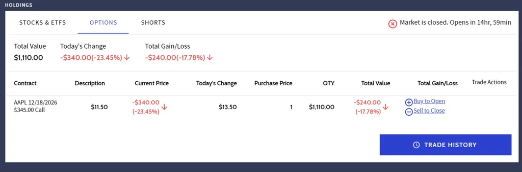

```r
# ============================================
# 10. CAPTURAS DE CME, TRADINGVIEW E INVESTOPEDIA
# ============================================

   capturas <- c(
     "investopedia_orden_ejecutada.png",
     "investopedia_portafolio.png",
     "tradingview_aapl_call_345.png",
     "cme_opciones.png"
   )

capturas_disponibles <- capturas[file.exists(capturas)]

if (length(capturas_disponibles) > 0) {
  knitr::include_graphics(capturas_disponibles)
} else {
  cat("Capturas pendientes de agregar en la carpeta 'capturas'.")
}
```

# 11. Conclusiones y recomendaciones

El análisis permitió integrar tres herramientas cuantitativas para evaluar el comportamiento de Apple Inc. y la rentabilidad potencial de una estrategia de opciones Call implementada en Investopedia.

En primer lugar, el modelo GARCH(1,1) permitió estimar la volatilidad condicional de AAPL utilizando información histórica de LSEG Workspace. Los resultados mostraron una persistencia moderada de la volatilidad (α + β = 0.8106), con un nivel de largo plazo cercano a 32% anual, por lo que el pronóstico sube hasta aproximadamente 31.37% al décimo día bursátil. Además, la volatilidad implícita en la cotización de Investopedia es prácticamente igual a la estimada por GARCH, lo que valida el modelo.

Posteriormente, mediante 10,000 simulaciones Monte Carlo, se obtuvo un precio promedio proyectado de USD 341.26 para AAPL durante un horizonte de dos semanas. La probabilidad estimada de superar el precio de ejercicio de USD 345 fue de 41.44%, lo que refleja la incertidumbre asociada a la evolución del subyacente.

Por su parte, el árbol binomial CRR de 200 pasos generó un valor teórico de USD 11.42 por acción para la Call americana, frente a una prima de adquisición de USD 13.50. Esta diferencia evidencia cómo el valor de una opción puede cambiar conforme evolucionan las condiciones del mercado y el tiempo restante al vencimiento.

Al comparar los resultados con Investopedia, se identificó una pérdida no realizada de USD 240, equivalente a −17.78% de la inversión inicial. La proyección a dos semanas generó una rentabilidad promedio de 4.34%, con una probabilidad de resultados positivos de 41.70%; sin embargo, esta ganancia depende en parte de que la volatilidad suba como pronostica el GARCH, como se muestra en la sección 8.4. Considerando la posición completa de AAPL en Investopedia (acciones, Put de protección y Call), el portafolio registra una ganancia de USD 192, porque la apreciación de las acciones compensa la pérdida de la Call y el costo de la protección.

**El principal hallazgo es que una rentabilidad esperada positiva no necesariamente implica una alta probabilidad de obtener ganancias.** En nuestra estrategia, los escenarios favorables pueden generar utilidades relevantes, pero existe una proporción considerable de resultados en los que no se recupera la prima inicial.

A partir de estos resultados, nuestra propuesta principal es convertir la posición en un Bull Call Spread 345/355, vendiendo una Call 355 de diciembre. Esto reduce el costo neto y el punto de equilibrio, y aumenta la probabilidad de terminar con ganancia al vencimiento ante una subida moderada de AAPL, a cambio de limitar la ganancia máxima. Adicionalmente, consideramos recomendable mantener un seguimiento de la volatilidad de AAPL, el comportamiento del precio respecto al strike de USD 345 y la evolución del valor temporal de la opción. Asimismo, sería conveniente comparar la volatilidad estimada mediante GARCH con la volatilidad implícita observada en el mercado, para identificar diferencias entre los supuestos estadísticos y las expectativas incorporadas en las primas.

Finalmente, los modelos utilizados constituyen herramientas de apoyo para la evaluación del riesgo y la toma de decisiones, pero sus resultados dependen de los supuestos de estimación y simulación. Por ello, las proyecciones deben interpretarse como escenarios posibles y no como garantías de rentabilidad futura.